# 簡単な漁業制御ルールの再現（工事中）

秋田 鉄也

2018/12/21 17:00

## 講習はパワーポイントのスライドを用いて、数式やコードを使わずに発表予定です

## 0. データのセット

齢構成がある種を対象として、簡単な漁業制御ルールをコンピューター上で再現することを目指す。以下のような状況を順に考えよう。

1. 漁業がない状況
2. 漁業が開始され資源が減少する過程
3. 管理基準値に基づいた資源管理が実施される過程

例えば、下記のような資源を考えよう。

```r
options(digits=4) # 出力を見やすくするため
age <- 10 # 最大年齢クラス（この場合０〜９歳）
maturity_age <- 5 # 成熟年齢
M_at_age <- rep(0.3,age) # 自然死亡率は齢に依らず一定と仮定
Q_at_age <- c(rep(0,maturity_age),rep(1,age-maturity_age)) # 成熟年齢に達すると100%成熟すると仮定
```

なお、性別については区別しない。重量については以下のようにvon-Bertalanffy式
$$W(a)=w_{\infty} ( 1-{\rm exp}[-K(a-a_0)] )^b$$
を仮定した。今回は詳細には立ち入らない。

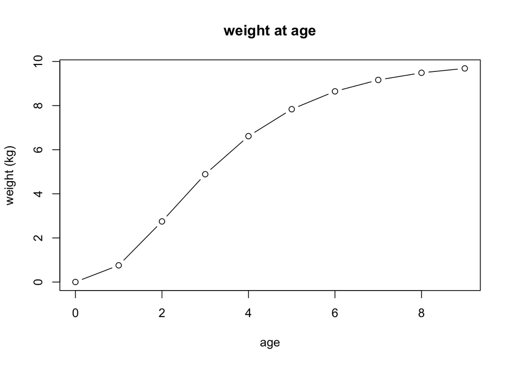

```r
# パラメータ
VB_a0 <- -0.1
VB_b <- 3
VB_K <- 0.5
VB_winf <- 10

VB <- function(a){
  VB_winf*(1 - exp(-VB_K*(a-VB_a0)) )^VB_b
}

W_at_age <- sapply(seq(0,age-1,1),VB)
plot(seq(0,(age-1),1),W_at_age,xlab = "age",ylab = "weight (kg)",main = "weight at age",type = "b")
```

再生産関係についてはBeverton Holt式
$$R=\frac{a SSB}{b + SSB}$$
を採用した。以下、加入個体数を$R$、産卵親魚重量を$SSB$(Spwainig Stock Biomass)と記載することがある。

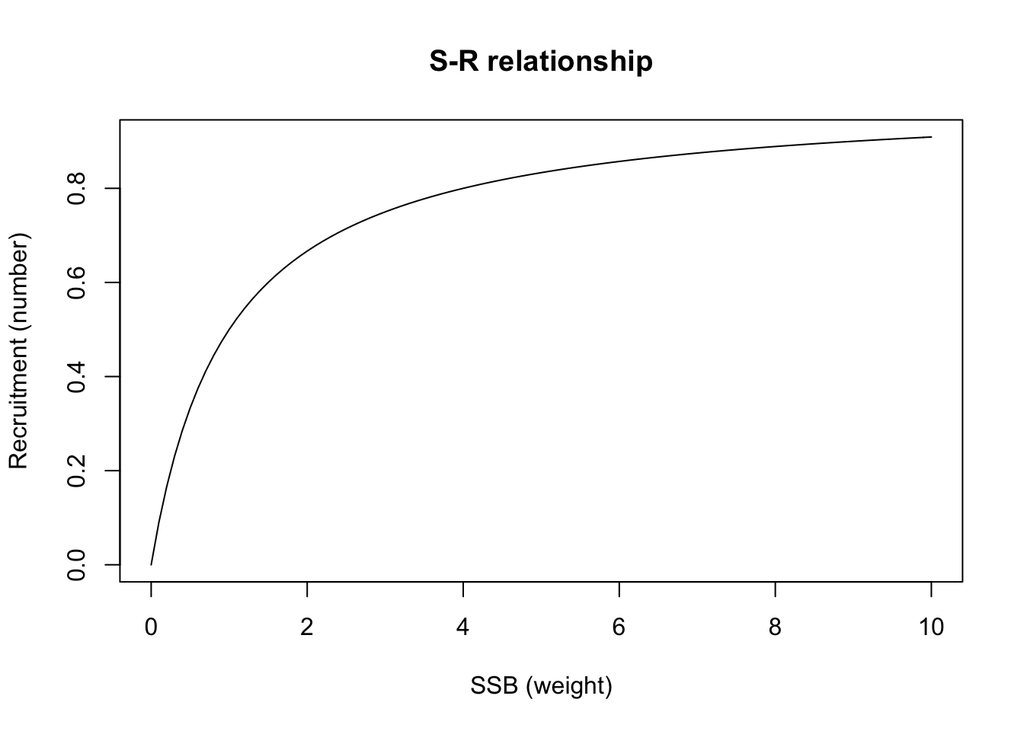

```r
# パラメータ
BH_a <- 1
BH_b <- 1

BH <- function(SSB,BH_a,BH_b){
  R <- BH_a * SSB / (BH_b + SSB)
  return(R)
}
curve(BH(x,BH_a,BH_b),from = 0,to = 10,xlab = "SSB (weight)",ylab = "Recruitment (number)",main="S-R relationship")
```

再生産関係をシミュレーションで再現する際に採用されたパラメータ($a$,$b$)の値は、管理基準値を計算する時に推定するが、今回は詳細には立ち入らない。また、単位（重量・尾数）は後から設定できるので、深く考えないで進める。

## 1. 漁業がない状況

0歳個体が5（単位）個体存在する状況を初期状態として10年後を見ることで、漁業がない状況における個体群動態を再現してみよう。理解のために、まずは環境変動はないと仮定する。

```r
burn_in <- 10 # 計算年数
SSB_init <- 5 # 初期加入個体
SSB <- c(SSB_init,rep(0,burn_in))
N_at_age <- rep(0,age)
for (y in 1:burn_in) {
  for (a in 1:age){
    if(a==1) {
      N_at_age[a] <- BH(SSB[y],BH_a,BH_b)
    }else{
      N_at_age[a] <- N_at_age[a-1] * exp(-M_at_age[a-1]) # exp[-M]は年生存率
    }
  }
  SSB[y+1] <- sum(N_at_age*Q_at_age*W_at_age)
}
print(SSB)
```

```
##  [1] 5.000 4.843 4.816 4.812 4.811 4.811 4.811 4.811 4.811 4.811 4.811
```

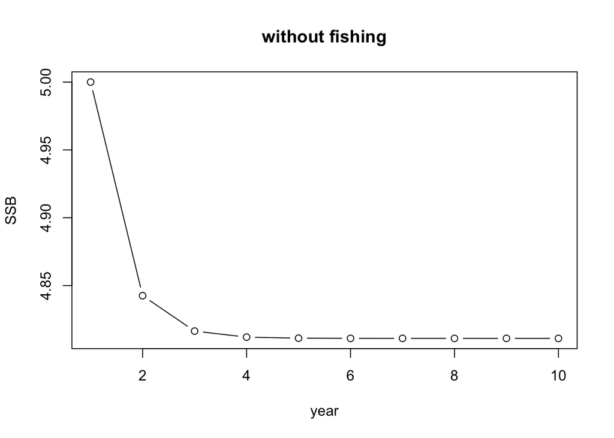

```r
plot(1:burn_in,SSB[1:burn_in],type = "b",xlab = "year",ylab = "SSB",main = "without fishing")
```

漁業がない場合、SSB=4.811が釣り合った（平衡）状態となる。平衡状態では、以下の2式
$$R=\frac{a SSB}{b + SSB}$$
$$SSB=SPR|_{F=0} R$$

を満たす($SSB$,$R$)の組み合わせが選ばれる。$SPR|_{F=0}$は、漁業がない場合の「加入あたりの産卵親魚量」に対応する。

```r
S_at_age <- c(1,rep(0,age-1))
for (a in 1:(age-1)){
  S_at_age[a+1] <- S_at_age[a] *exp(-M_at_age[a])
}
print(S_at_age) # 加入個体のx年後までの生存率(x=1~9)
```

```
##  [1] 1.00000 0.74082 0.54881 0.40657 0.30119 0.22313 0.16530 0.12246
##  [9] 0.09072 0.06721
```

```r
SPR0 <- sum(S_at_age * W_at_age * Q_at_age)
print(SPR0) # 加入1個体の産卵親魚量(kg)への貢献量
```

```
## [1] 5.811
```

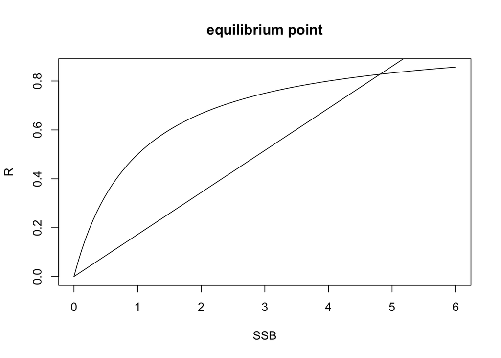

```r
curve(expr =  BH_a * x / (BH_b + x),from = 0,to=6,xlab = "SSB",ylab = "R",main="equilibrium point")
curve(expr = x/SPR0,add = T)
```

2つの関係式を図示してみると上のようになり、交点が平衡点に相当する。

## 2. 漁業が開始され資源が減少する過程

```r
SSB_init2 <- SSB[y+1] # 漁業がない状態を初期状態とする
F_at_age <- rep(0.25,age) # 漁獲死亡係数は齢に依らず一定と仮定
term <- 50 # 操業期間
sd <- 0.3 # 加入の変動係数
sd2 <- 0.1 # 漁獲の変動係数
SSB2 <- c(SSB_init2,rep(0,term))
Catch <- rep(0,term)
N_at_age_mat <- F_tmp0 <- matrix(0,nrow = term+1,ncol=age)
N_at_age_mat[1,] <- N_at_age
for (y in 1:term) {
  F_tmp0[y,] <- F_at_age * exp(rnorm(1,mean = 0,sd = sd2)-sd2^2/2)# 誤差の影響を含むので、毎年更新される
  Catch[y] <- sum(
    F_tmp0[y,]/(F_tmp0[y,]+M_at_age)*(1-exp(-F_tmp0[y,]-M_at_age))*N_at_age_mat[y,]*W_at_age
  )
  for (a in 1:age){
    if(a==1) {
      N_at_age_mat[y+1,a] <- BH(SSB2[y],BH_a,BH_b)* exp(rnorm(1,mean = 0,sd = sd)-sd^2/2)
    }else{
      N_at_age_mat[y+1,a] <- N_at_age_mat[y,a-1] * exp(-M_at_age[a-1]-F_tmp0[y,a-1]) # exp[-M-F]は年生存率
    }
  }
  SSB2[y+1] <- sum(N_at_age_mat[y+1,]*Q_at_age*W_at_age)
}
print(SSB2)
```

```
##  [1] 4.8111 3.8081 2.9761 2.3369 1.8683 1.4271 1.2281 0.8974 0.8694 0.7580
## [11] 0.8772 1.0395 0.8773 0.6993 0.6872 0.7058 0.5371 0.4736 0.5005 0.4973
## [21] 0.3682 0.3673 0.3760 0.3418 0.3426 0.4307 0.3855 0.3443 0.3166 0.3238
## [31] 0.3046 0.3073 0.3408 0.3499 0.3317 0.2857 0.2389 0.2314 0.2610 0.2645
## [41] 0.2812 0.2720 0.2731 0.2395 0.2129 0.2309 0.2042 0.2368 0.2170 0.1909
## [51] 0.1799
```

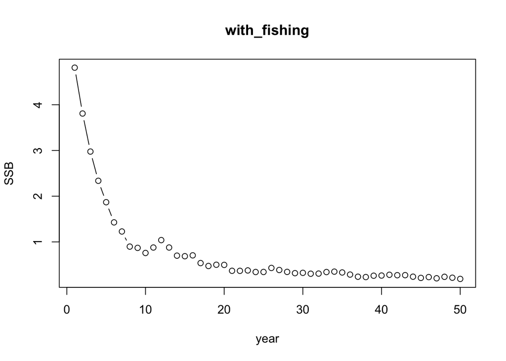

```r
plot(1:term,SSB2[1:term],type = "b",xlab = "year",ylab = "SSB",main = "with_fishing")
```

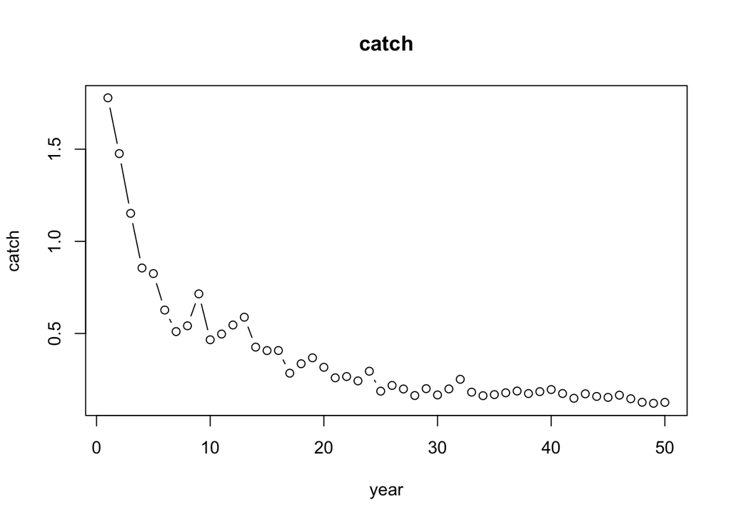

```r
plot(1:term,Catch,type = "b",xlab = "year",ylab = "catch",main = "catch")
```

この漁獲死亡係数の下では、50年間で産卵親魚量が大きく減少することがわかる。同時に、漁獲量も開発初期から徐々に減少していく。SPRについても計算してみよう。

```r
S_at_age <- c(1,rep(0,age-1))
for (a in 1:(age-1)){
  S_at_age[a+1] <- S_at_age[a] * exp(-M_at_age[a]-F_at_age[a])
}
SPR1 <- sum(S_at_age * W_at_age * Q_at_age)
print(SPR1) # なお、a*SPR1 - b < 0で絶滅する
```

```
## [1] 1.2
```

```r
print(SPR1/SPR0) # %SPR（漁業がない状態のSPRで割ったSPR）
```

```
## [1] 0.2065
```

%SPRは約21%と計算されるが、これは漁業がない状態を100%と考え、20%の産卵親魚量をとり残すような状況であることを示唆している。SPRが計算されたことから、（確率的変動がない場合の）平衡状態の($SSB$,$R$)も計算できる。

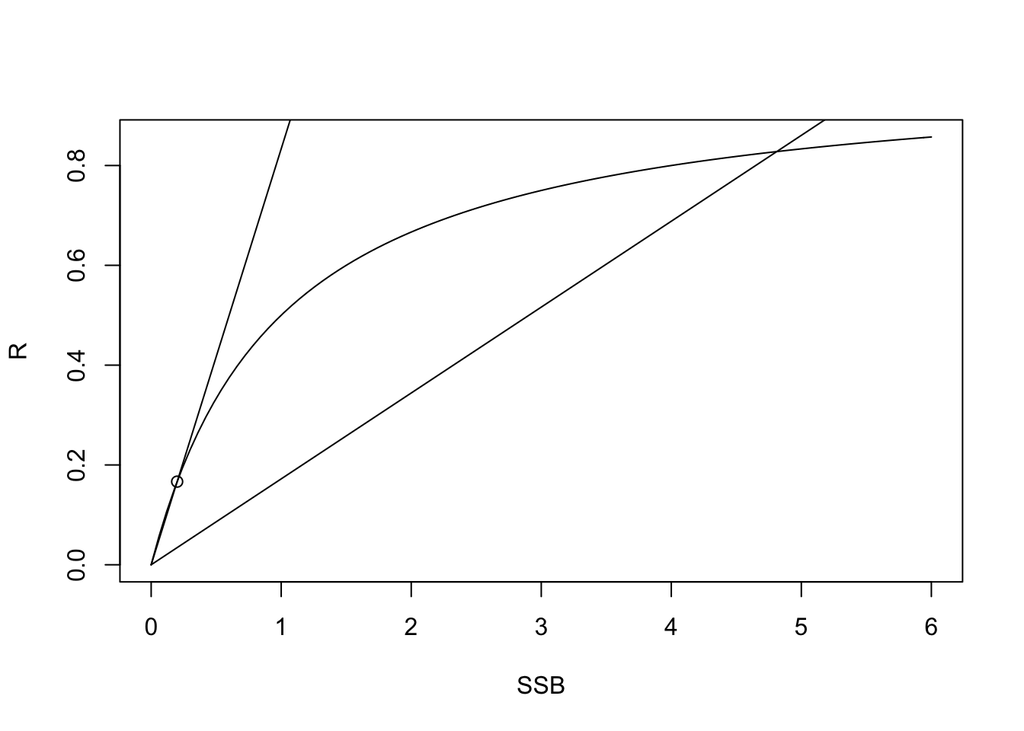

```r
curve(expr =  BH_a * x / (BH_b + x),from = 0,to=6,xlab = "SSB",ylab = "R")
curve(expr = x/SPR0,add = T)
curve(expr = x/SPR1,add = T)
SSB_eq <- BH_a * SPR1 - BH_b # SSBとRに関する連立方程式を解くと出てくる
points(x = SSB_eq, y=BH(SSB_eq,BH_a,BH_b))
```

交点はSSB=0よりも少し大きい所に存在する。さて、本来であれば漁獲量データやCPUE指標値などから標資源量の推定をすることで、産卵親魚量や加入量が推定されるのだが、今回はこれら50年分の値は既知としよう。これら50個の($SSB$,$R$)の組み合わせから再生産関係を推定してみる。今回は資源評価で利用されているコード“rvpa1.9.2.r”と“future2.1.r”をソースとして読み込んで、最尤推定を実施する。

```r
source("rvpa1.9.2.r")
source("future2.1.r")
SRdata <- get.SRdata(R.dat = N_at_age_mat[2:(term+1),1], SSB.dat = SSB2[1:term] )
BH.par0 <- fit.SR(SRdata, SR = "BH", method = "L2", AR = 0, hessian = FALSE)
plot.SRdata(SRdata)
print(BH.par0$pars) # 推定結果(BH_a, BH_b, sd, 自己相関の強さ（今回は用いてない）)
```

```
##        a     b     sd rho
## 1 0.9533 1.066 0.2599   0
```

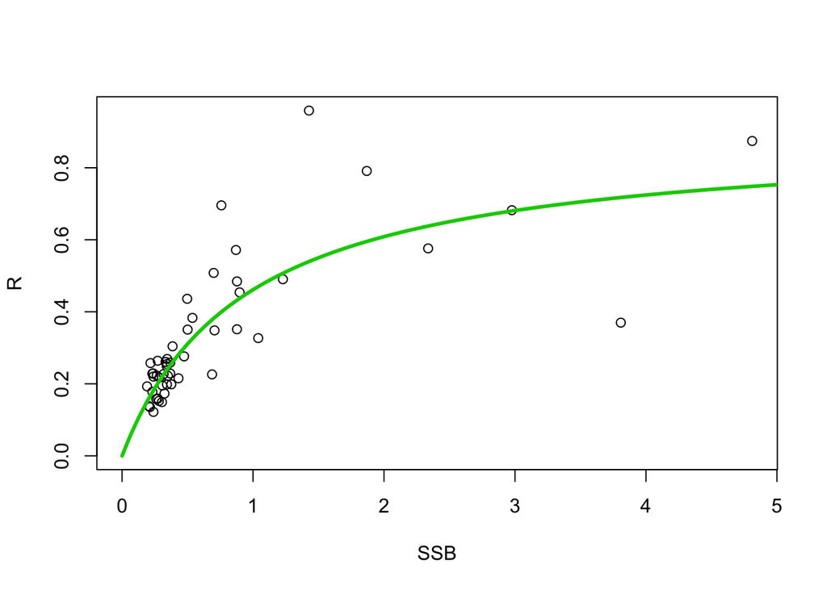

```r
points(BH.par0$pred$SSB, BH.par0$pred$R, col = 3, type = "l", lwd = 3)
```

確率的挙動を含むことから、再生産関係の真の値は理論カーブから大きく揺らぐ。

## 3. 管理基準値に基づいた資源管理が実施される過程

これまで設定されていた漁獲強度は、未開発時の21%を取り残す程度の漁獲圧であった。水産資源解析の研究によると、30%~40%を取り残すのが良いとされている。そこで未開発時の30%を取り残すには、現状の漁獲圧からどれだけ減らさなくてはならないかを考えよう。

```r
f_mulitplier <- seq(0,1.5,0.01)
f_len <- length(f_mulitplier)
SPR_res <- rep(0,f_len)
for (i in 1:f_len){

  S_at_age <- c(1,rep(0,age-1))
  for (a in 1:(age-1)){
    S_at_age[a+1] <- S_at_age[a] * exp(-M_at_age[a]- f_mulitplier[i] * F_at_age[a])
  }
  SPR_res[i] <- sum(S_at_age * W_at_age * Q_at_age)/SPR0
}
```